# Reproducible Research: Peer Assessment 1

## Loading and preprocessing the data

```r
# clear workspace
rm(list=ls())

# load necessary packages
library(rprojroot)
library(knitr)
library(data.table)
library(tidyverse)
library(lubridate)
library(ggplot2)

# source files within this project
path <- function(x) find_root_file(x, criterion = has_file('RepData_PeerAssessment1.Rproj'))
```

```r
# unzip data file
dataFile <- unzip(path('activity.zip'))

# load data into dataframe
data <- fread(dataFile)
```

## What is mean total number of steps taken per day?

```r
# create a summary dataframe with total steps per day
totalStepsData <- data %>%
  mutate(date = ymd(date)) %>%
  group_by(date) %>%
  summarize(totalSteps = sum(steps, na.rm = TRUE))

# calculate mean steps per day
meanStepsVal <- mean(totalStepsData$totalSteps, na.rm = TRUE)

# calculate median steps per day
medianStepsVal <- median(totalStepsData$totalSteps, na.rm = TRUE)
```

The mean total number of steps taken per day is 9354.23. The median total number of steps per day is 10395.

A histogram of total steps per day is shown below:

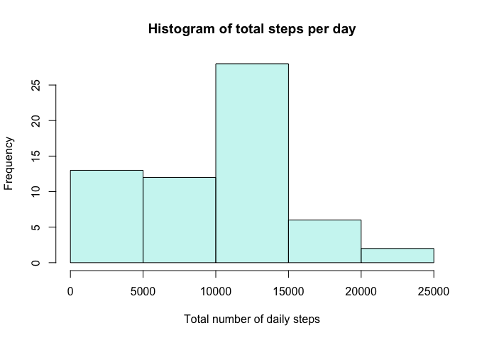

```r
# create histogram of total number of steps per day
hist(totalStepsData$totalSteps,
     col = alpha("turquoise", 0.3),
     xlab = 'Total number of daily steps',
     ylab = 'Frequency',
     main = 'Histogram of total steps per day')
```

## What is the average daily activity pattern?

```r
# summarize steps per interval, averaged across days
stepsByIntervalData <- data %>%
  group_by(interval) %>%
  summarize(meanSteps = mean(steps, na.rm = TRUE))

# which 5-minute interval contains max number of steps?
maxInterval <- stepsByIntervalData$interval[which.max(stepsByIntervalData$meanSteps)]
```

Interval 835 contains the maximum number of steps, when averaged across all days.

A time series plot of mean steps per 5-minute time interval, averaged across days, is shown below.

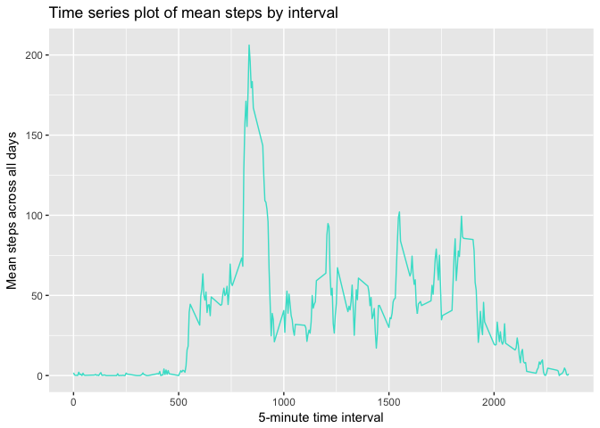

```r
ggplot(stepsByIntervalData, aes(x = interval, y = meanSteps)) +
  geom_line(colour = "turquoise") +
  labs(x = '5-minute time interval',
       y = 'Mean steps across all days',
       title = 'Time series plot of mean steps by interval')
```